# Customer Segmentation using K-means Clustering in R

# Summary Of Spending Score

```r
summary(customer_data$Spending.Score..1.100.)
```

```
   Min. 1st Qu.  Median    Mean 3rd Qu.    Max.
   1.00   34.75   50.00   50.20   73.00   99.00
```

# Visualization of Age and Gender together

```r
library(ggplot2)
bold_axis <- element_text(face = "bold", color = "black", size = 20)
axis_text <- element_text(face = "bold", size = 14)
# bold axis is used for the text characteristics of headings of the graphs
# axis_text is used for the text characteristics of labels of the graphs
```

# Histogram of Customer Age

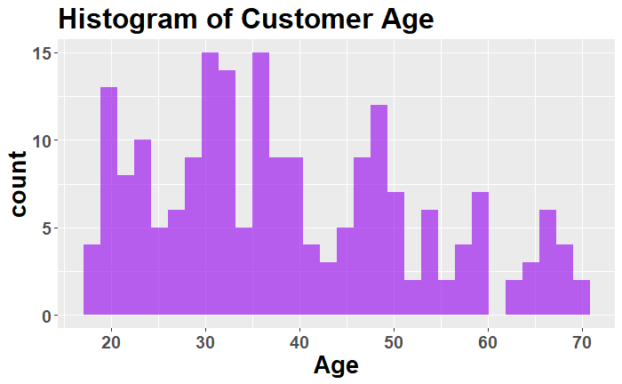

```r
Plotage <- ggplot(customer_data,aes(x=Age))
Plotage + geom_histogram(fill="purple", alpha = 0.7,bins=30) + theme(axis.text = axis_text) + theme(title = bold_axis) + ggtitle("Histogram of Customer Age")
```

# Visualization of customers by age and gender

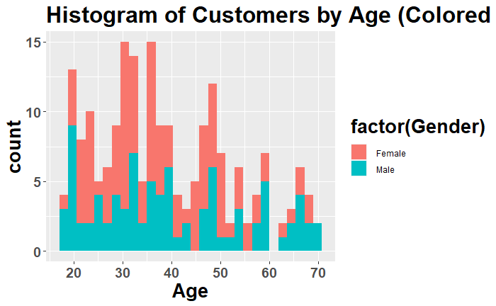

```r
Plotagegender <- ggplot(customer_data, aes(x = Age))

Plotagegender + geom_histogram(aes(fill = factor(Gender)),bins=30) + ggtitle("Histogram of Customers by Age (Colored by Gender)") + theme(axis.text = axis_text) + theme(title = bold_axis)
```

# K-Means Clustering

K-means is a centroid-based algorithm, or a distance-based algorithm, where we calculate the distances to assign a point to a cluster. In K-Means, each cluster is associated with a centroid.

There are three methods to find the optimal number of clusters : 1.Elbow Method 2.Silhouette Method 3.Gap-statistic Method

we need libraries like ggplot2,dplyr,cluster,factoextra for implementing k-means clustering

```r
library(ggplot2)
library(dplyr)
library(cluster)
library(factoextra)
```

For simplicity reasons , we are renaming the attribute names to cust_id,gender,age,annual_income_000,spend_score

```r
colnames(customer_data) <- c("cust_id","gender","age","annual_income_000","spend_score")
```

# 1. Elbow Method

In cluster analysis, the elbow method is a heuristic used in determining the number of clusters in a data set. The method consists of plotting the explained variation as a function of the number of clusters, and picking the elbow of the curve as the number of clusters to use.

Here we are performing the elbow method on spending_score and annual_income.

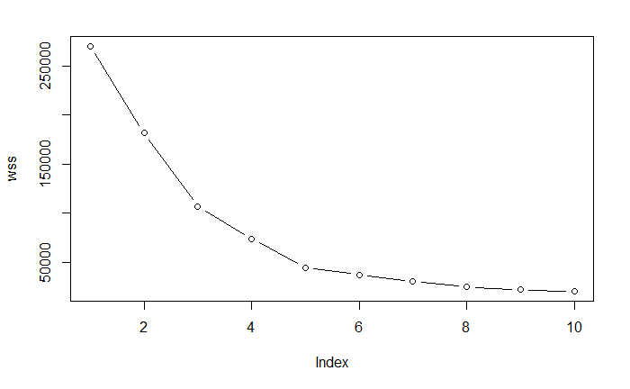

```r
kk <- 1:10
wss <- c()
for (i in kk){
  cluster_temp <- kmeans(customer_data[,c(4,5)], centers = i, nstart = 25)
  wss <- c(wss, cluster_temp$tot.withinss)
}
plot(wss, type = "b")
```

# 2. Average Silhouette Method

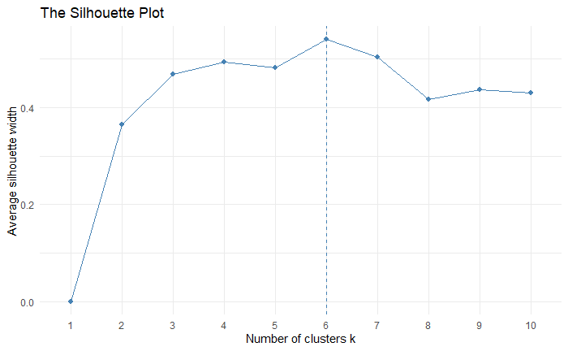

```r
fviz_nbclust(customer_data[,c(4,5)], kmeans, method = "silhouette", k.max = 10) + theme_minimal() + ggtitle("The Silhouette Plot")
```

# 3. Gap-Statistic Method

```r
set.seed(123)
gap_stat <- clusGap(customer_data[,c(4,5)], FUN = kmeans, nstart = 25, K.max = 10, B = 50)
```

```
Clustering k = 1,2,..., K.max (= 10): .. done
Bootstrapping, b = 1,2,..., B (= 50)  [one "." per sample]:
.................................................. 50
```

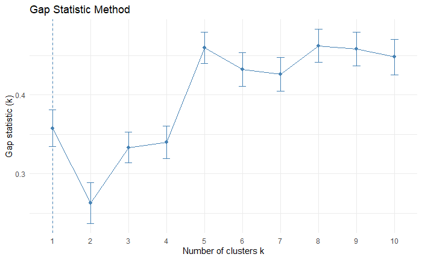

```r
fviz_gap_stat(gap_stat) + theme_minimal() + ggtitle("Gap Statistic Method")
```

# Gap - Statistic Method Explanation

```r
set.seed(123)
gap_stat <- clusGap(customer_data[,c(4,5)], FUN = kmeans, nstart = 25, K.max = 10, B = 50)
```

```
Clustering k = 1,2,..., K.max (= 10): .. done
Bootstrapping, b = 1,2,..., B (= 50)  [one "." per sample]:
.................................................. 50
```

```r
print(gap_stat, method = "firstmax")
```

```
Clustering Gap statistic ["clusGap"] from call:
clusGap(x = customer_data[, c(4, 5)], FUNcluster = kmeans, K.max = 10,     B = 50, nstart = 25)
B=50 simulated reference sets, k = 1..10; spaceH0="scaledPCA"
 --> Number of clusters (method 'firstmax'): 1
          logW   E.logW       gap     SE.sim
 [1,] 7.726954 8.084772 0.3578183 0.02362926
 [2,] 7.505361 7.768072 0.2627115 0.02586123
 [3,] 7.217243 7.550513 0.3332702 0.01952559
 [4,] 7.025623 7.365545 0.3399223 0.02039133
 [5,] 6.784776 7.244922 0.4601450 0.01986343
 [6,] 6.708467 7.140781 0.4323140 0.02150319
 [7,] 6.625887 7.052212 0.4263249 0.02117973
 [8,] 6.509687 6.972256 0.4625686 0.02085269
 [9,] 6.440290 6.898833 0.4585429 0.02124844
[10,] 6.385390 6.833580 0.4481897 0.02270071
```

From the above methods the optimal number of clustering can be done with either k=5 or k=6 # K = 5 Clustering According to Spending Score and Annual Income: considering the number of optimal number of clusters = 5

```r
set.seed(10)
cluster_5 <- kmeans(customer_data[,c(4,5)], centers = 5, nstart = 25)
cluster_5
```

```
K-means clustering with 5 clusters of sizes 39, 22, 81, 35, 23

Cluster means:
  annual_income_000 spend_score
1          86.53846    82.12821
2          25.72727    79.36364
3          55.29630    49.51852
4          88.20000    17.11429
5          26.30435    20.91304

Clustering vector:
  1   2   3   4   5   6   7   8   9  10  11  12  13  14  15  16  17  18  19  20  21  22  23  24  25  26  27  28  29
  5   2   5   2   5   2   5   2   5   2   5   2   5   2   5   2   5   2   5   2   5   2   5   2   5   2   5   2   5
 30  31  32  33  34  35  36  37  38  39  40  41  42  43  44  45  46  47  48  49  50  51  52  53  54  55  56  57  58
  2   5   2   5   2   5   2   5   2   5   2   5   2   5   3   5   2   3   3   3   3   3   3   3   3   3   3   3   3
 59  60  61  62  63  64  65  66  67  68  69  70  71  72  73  74  75  76  77  78  79  80  81  82  83  84  85  86  87
  3   3   3   3   3   3   3   3   3   3   3   3   3   3   3   3   3   3   3   3   3   3   3   3   3   3   3   3   3
 88  89  90  91  92  93  94  95  96  97  98  99 100 101 102 103 104 105 106 107 108 109 110 111 112 113 114 115 116
  3   3   3   3   3   3   3   3   3   3   3   3   3   3   3   3   3   3   3   3   3   3   3   3   3   3   3   3   3
117 118 119 120 121 122 123 124 125 126 127 128 129 130 131 132 133 134 135 136 137 138 139 140 141 142 143 144 145
  3   3   3   3   3   3   3   1   4   1   3   1   4   1   4   1   3   1   4   1   4   1   4   1   4   1   3   1   4
146 147 148 149 150 151 152 153 154 155 156 157 158 159 160 161 162 163 164 165 166 167 168 169 170 171 172 173 174
  1   4   1   4   1   4   1   4   1   4   1   4   1   4   1   4   1   4   1   4   1   4   1   4   1   4   1   4   1
175 176 177 178 179 180 181 182 183 184 185 186 187 188 189 190 191 192 193 194 195 196 197 198 199 200
  4   1   4   1   4   1   4   1   4   1   4   1   4   1   4   1   4   1   4   1   4   1   4   1   4   1

Within cluster sum of squares by cluster:
[1] 13444.051  3519.455  9875.111 12511.143  5098.696
 (between_SS / total_SS =  83.5 %)

Available components:

[1] "cluster"      "centers"      "totss"        "withinss"     "tot.withinss" "betweenss"    "size"
[8] "iter"         "ifault"
```

As we see in the Clustering Vector all the 200 points in the data-set have been classified into 5 different clusters.

Now we are modifying the data-set by adding the cluster number to each corresponding point using mutate.

```r
library(dplyr)
library(magrittr)
customer_data <- customer_data %>% mutate(cluster5 = cluster_5$cluster)
```

Printing the data-set after adding the cluster number

```r
customer_data
```

| cust_id | gender | age | annual_income_000 | spend_score | cluster5 |
| --- | --- | --- | --- | --- | --- |
| 1 | Male | 19 | 15 | 39 | 5 |
| 2 | Male | 21 | 15 | 81 | 2 |
| 3 | Female | 20 | 16 | 6 | 5 |
| 4 | Female | 23 | 16 | 77 | 2 |
| 5 | Female | 31 | 17 | 40 | 5 |
| 6 | Female | 22 | 17 | 76 | 2 |
| 7 | Female | 35 | 18 | 6 | 5 |
| 8 | Female | 23 | 18 | 94 | 2 |
| 9 | Male | 64 | 19 | 3 | 5 |
| 10 | Female | 30 | 19 | 72 | 2 |

[output cut: 190 more lines]

# Printing a Scatter Plot for the above data (K = 5)

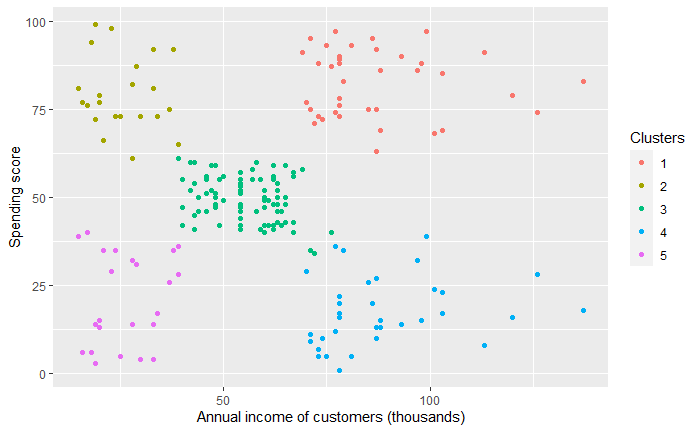

```r
library(ggplot2)
ggplot(customer_data, aes(x = annual_income_000, y = spend_score, colour = factor(cluster5))) +
  geom_point() +
  scale_color_discrete(name = "Clusters") +
  xlab("Annual income of customers (thousands)") +
  ylab("Spending score")
```

The conclusions from the above graph are :

cluster 1 : High Annual Income and High Spending Score Cluster 2 : Low Annual Income and High Spending Score Cluster 3 : Average Annual Income and Average Spending Score Cluster 4 : High Annual Income and Low spending score Cluster 5 : Low Annual Income and Low spending score

Till now we considered only the attributes spending score and annual income

# K = 6

```r
k6<-kmeans(customer_data[,3:5],6,iter.max=100,nstart=100)
k6
```

```
K-means clustering with 6 clusters of sizes 21, 39, 38, 35, 45, 22

Cluster means:
       age annual_income_000 spend_score
1 44.14286          25.14286    19.52381
2 32.69231          86.53846    82.12821
3 27.00000          56.65789    49.13158
4 41.68571          88.22857    17.28571
5 56.15556          53.37778    49.08889
6 25.27273          25.72727    79.36364

Clustering vector:
  [1] 1 6 1 6 1 6 1 6 1 6 1 6 1 6 1 6 1 6 1 6 1 6 1 6 1 6 1 6 1 6 1 6 1 6 1 6 1 6 1 6 5 6 5 3 1 6 5 3 3 3 5 3 3 5 5
 [56] 5 5 5 3 5 5 3 5 5 5 3 5 5 3 3 5 5 5 5 5 3 5 3 3 5 5 3 5 5 3 5 5 3 3 5 5 3 5 3 3 3 5 3 5 3 3 5 5 3 5 3 5 5 5 5
[111] 5 3 3 3 3 3 5 5 5 5 3 3 3 2 3 2 4 2 4 2 4 2 3 2 4 2 4 2 4 2 4 2 3 2 4 2 4 2 4 2 4 2 4 2 4 2 4 2 4 2 4 2 4 2 4
[166] 2 4 2 4 2 4 2 4 2 4 2 4 2 4 2 4 2 4 2 4 2 4 2 4 2 4 2 4 2 4 2 4 2 4 2

Within cluster sum of squares by cluster:
[1]  7732.381 13972.359  7742.895 16690.857  8062.133  4099.818
 (between_SS / total_SS =  81.1 %)

Available components:

[1] "cluster"      "centers"      "totss"        "withinss"     "tot.withinss" "betweenss"    "size"
[8] "iter"         "ifault"
```

# Plotting Customer Age with Spending Score (K = 6)

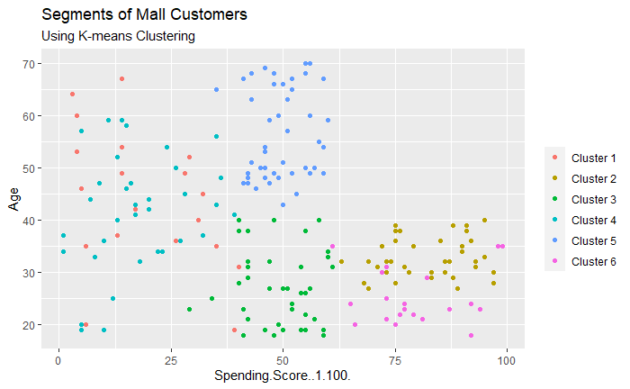

```r
ggplot(df, aes(x =Spending.Score..1.100., y =Age)) +
  geom_point(aes(color = as.factor(k6$cluster))) +
  scale_color_discrete(name=" ",
                      breaks=c("1", "2", "3", "4", "5","6"),
                      labels=c("Cluster 1", "Cluster 2", "Cluster 3", "Cluster 4", "Cluster 5","Cluster 6")) +
  ggtitle("Segments of Mall Customers", subtitle = "Using K-means Clustering")
```

# Principal Component Analysis

As there are three attributes for the execution: Age,Spending Score,Annual Income.

We will be getting a three dimensional point (x,y,z) Principal component analysis is the process of flattening the data set so that we can convert the three dimensional point into a two dimensional point.

We will be getting 3 rotation points PC1,PC2,PC3 where the variation among these is in the following order : PC1>PC2>PC3

```r
pcclust=prcomp(customer_data[,3:5])
pcclust
```

```
Standard deviations (1, .., p=3):
[1] 26.46251 26.15970 12.93169

Rotation (n x k) = (3 x 3):
                         PC1        PC2         PC3
age                0.1889742 -0.1309652 0.973209570
annual_income_000 -0.5886410 -0.8083757 0.005516668
spend_score       -0.7859965  0.5739136 0.229853647
```

# Summary of Principal Component Analysis

```r
summary(pcclust)
```

```
Importance of components:
                           PC1     PC2     PC3
Standard deviation     26.4625 26.1597 12.9317
Proportion of Variance  0.4512  0.4410  0.1078
Cumulative Proportion   0.4512  0.8922  1.0000
```

as PC1 has the highest variation

```r
pcclust$rotation[,1:2]
```

```
                         PC1        PC2
age                0.1889742 -0.1309652
annual_income_000 -0.5886410 -0.8083757
spend_score       -0.7859965  0.5739136
```

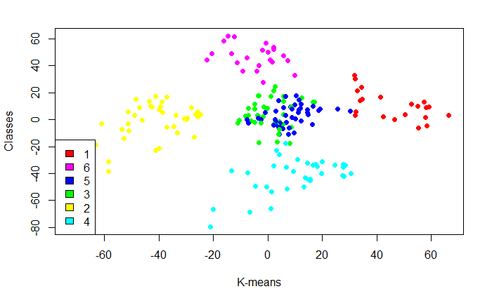

```r
kCols=function(vec){cols=rainbow (length (unique (vec)))
return (cols[as.numeric(as.factor(vec))])}

digCluster<-k6$cluster; dignm<-as.character(digCluster); # K-means clusters

plot(pcclust$x[,1:2], col = kCols(digCluster),pch = 19,xlab = "K-means",ylab= "Classes")
legend("bottomleft",unique(dignm),fill=unique(kCols(digCluster)))
```